# NOAA GOM Shark Models

Alex Benecke

July 2, 2018

## Data Exploration

| Variable | n NAs |
| --- | --- |
| YEAR | 0 |
| STARTLAT | 0 |
| STARTLON | 0 |
| AVG.DEPTH | 1 |
| TEMPBOTM | 168 |
| FLUOROBOTM | 1869 |
| TURBBOTM | 925 |
| OXYBOTM | 186 |
| SALBOTM | 179 |
| dombot8 | 38 |
| dombot4 | 38 |

*FLUOROBOTM* and *TURBBOTM* will be removed from the analysis due to the high proportion of NA values. This leaves 223 NAs in the data spread among the remaining variables.

```
##               AVG.DEPTH    TEMPBOTM  FLUOROBOTM     TURBBOTM      OXYBOTM
## AVG.DEPTH   1.000000000 -0.86864383 -0.44172196 -0.007570984 -0.181232682
## TEMPBOTM   -0.868643827  1.00000000  0.46201797 -0.045229166  0.218761967
## FLUOROBOTM -0.441721960  0.46201797  1.00000000 -0.208071038  0.102506513
## TURBBOTM   -0.007570984 -0.04522917 -0.20807104  1.000000000  0.230459145
## OXYBOTM    -0.181232682  0.21876197  0.10250651  0.230459145  1.000000000
## SALBOTM     0.221428454 -0.34288151 -0.08971851  0.367424834 -0.004272309
##                 SALBOTM
## AVG.DEPTH   0.221428454
## TEMPBOTM   -0.342881507
## FLUOROBOTM -0.089718508
## TURBBOTM    0.367424834
## OXYBOTM    -0.004272309
## SALBOTM     1.000000000
```

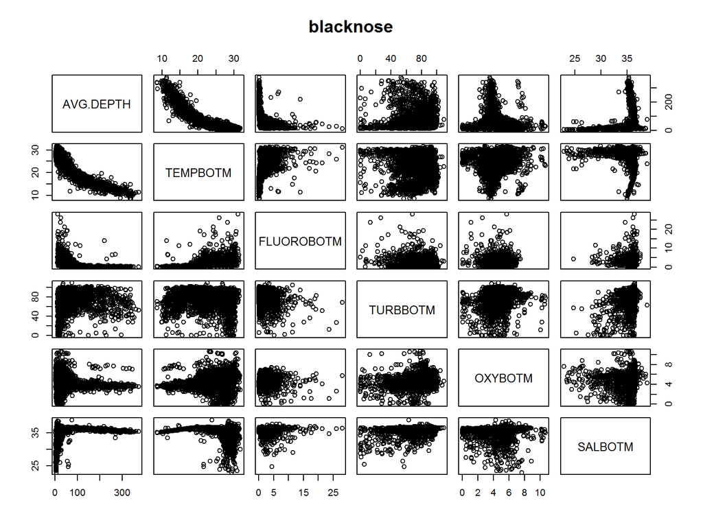

| species | depth_variance | temp_variance |
| --- | --- | --- |
| blacknose | 4605.976 | 27.0407 |
| blacktip | 4605.976 | 27.0407 |
| bull | 4605.976 | 27.0407 |
| sandbar | 4605.976 | 27.0407 |
| sharpnose | 4605.976 | 27.0407 |
| silky | 4605.976 | 27.0407 |
| spinner | 4605.976 | 27.0407 |
| tiger | 4605.976 | 27.0407 |

### Descriptive Stats

#### Number of Sites with Positive Catch

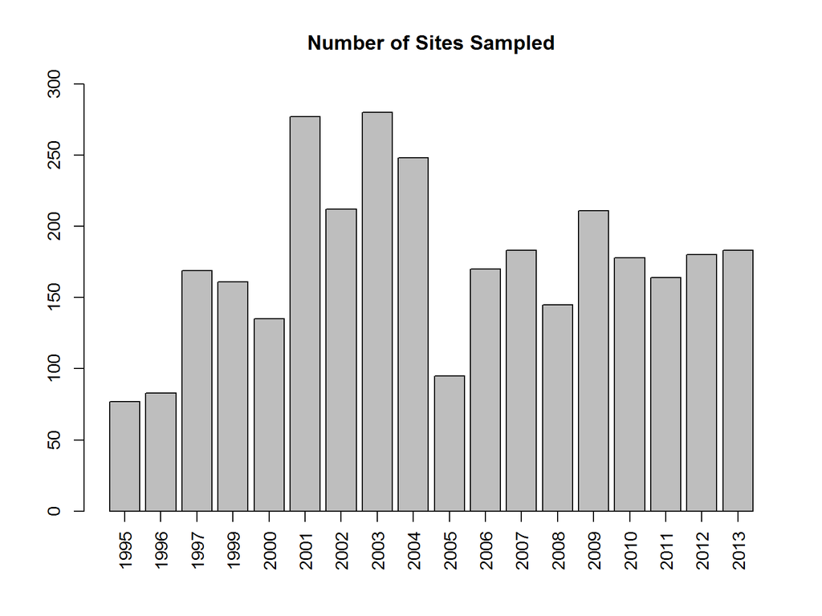

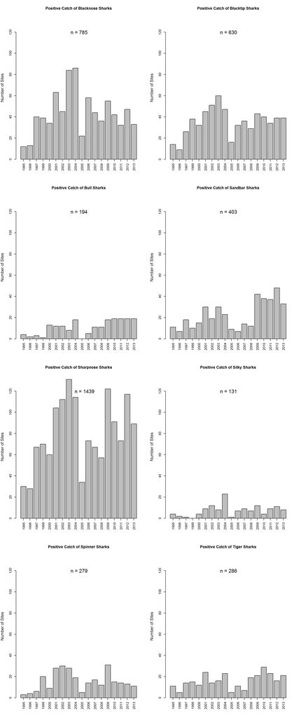

#### Annual Mean cpe

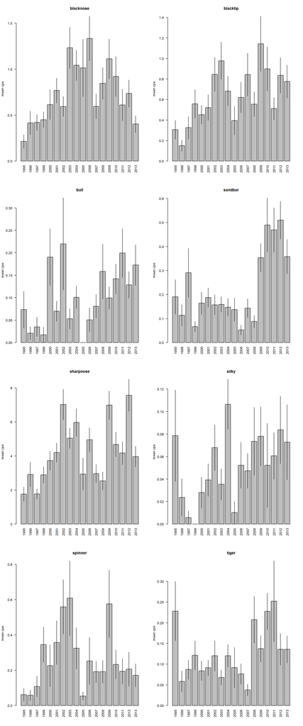

## Model Selection

### Blacknose

| Model Terms | AIC | BIC | GCV |
| --- | --- | --- | --- |
| AVG.DEPTH, OXYBOTM, SALBOTM | 6827 | 7874 | 0.30828*** |
| AVG.DEPTH, SALBOTM | 6866 | 7891 | 0.31019 |
| OXYBOTM, SALBOTM | 6868 | 7907 | 0.31217 |
| AVG.DEPTH, OXYBOTM | 6900 | 7702*** | 0.31455 |
| SALBOTM | 6922 | 7917 | 0.31558 |
| OXYBOTM | 6942 | 7726 | 0.31865 |
| AVG.DEPTH | 7367 | 8159 | 0.3194 |
| Mod 0 | 7414 | 8174 | 0.32368 |

**Note:** All models contain *STARTLON*, *STARTLAT*, and random effects for *YEAR*. **Mod0** is *(cpe +1) ~ s(STARTLON, STARTLAT) + s(YEAR, bs = “re”)*.

### Blacktip

| Model Terms | AIC | BIC | GCV |
| --- | --- | --- | --- |
| AVG.DEPTH, OXYBOTM, SALBOTM | 5770 | 6847 | 0.23938*** |
| OXYBOTM, SALBOTM | 5813 | 6860 | 0.2425 |
| AVG.DEPTH, SALBOTM | 5826 | 6869 | 0.24205 |
| SALBOTM | 5875 | 6888 | 0.24571 |
| AVG.DEPTH, OXYBOTM | 5964 | 6688*** | 0.25357 |
| OXYBOTM | 6025 | 6731 | 0.2585 |
| AVG.DEPTH | 6244 | 6970 | 0.25006 |
| Mod 0 | 6298 | 7009 | 0.25406 |

**Note:** All models contain *STARTLON*, *STARTLAT*, and random effects for *YEAR*. **Mod0** is *(cpe +1) ~ s(STARTLON, STARTLAT) + s(YEAR, bs = “re”)*.

### Bull

[output not shown]

**Note:** All models contain *STARTLON*, *STARTLAT*, and random effects for *YEAR*. **Mod0** is *(cpe +1) ~ s(STARTLON, STARTLAT) + s(YEAR, bs = “re”)*.

### Sandbar

| Model Terms | AIC | BIC | GCV |
| --- | --- | --- | --- |
| AVG.DEPTH, OXYBOTM, SALBOTM | 2880 | 3612 | 0.11978 |
| AVG.DEPTH, OXYBOTM | 2885 | 3597 | 0.1199 |
| AVG.DEPTH, SALBOTM | 2886 | 3571 | ***0.11973 |
| OXYBOTM, SALBOTM | 2987 | 3804 | 0.12414 |
| SALBOTM | 3007 | 3775 | 0.12467 |
| OXYBOTM | 3011 | 3759 | 0.12503 |
| AVG.DEPTH | 3137 | 3815 | 0.12218 |
| Mod 0 | 3274 | 4007 | 0.12751 |

**Note:** All models contain *STARTLON*, *STARTLAT*, and random effects for *YEAR*. **Mod0** is *(cpe +1) ~ s(STARTLON, STARTLAT) + s(YEAR, bs = “re”)*.

### Sharpnose

[output not shown]

**Note:** All models contain *STARTLON*, *STARTLAT*, and random effects for *YEAR*. **Mod0** is *(cpe +1) ~ s(STARTLON, STARTLAT) + s(YEAR, bs = “re”)*.

### Silky

| Model Terms | AIC | BIC | GCV |
| --- | --- | --- | --- |
| AVG.DEPTH, SALBOTM | -1548 | -882 | ***0.03246 |
| AVG.DEPTH, OXYBOTM, SALBOTM | -1538 | -830 | 0.03253 |
| AVG.DEPTH, OXYBOTM | -1536 | -857 | 0.03255 |
| AVG.DEPTH | -1490 | -774 | 0.03401 |
| OXYBOTM | -1474 | -812 | 0.03324 |
| SALBOTM | -1471 | -863 | 0.03331 |
| OXYBOTM, SALBOTM | -1463 | -812 | 0.03335 |
| Mod 0 | -1354 | -748 | 0.03549 |

**Note:** All models contain *STARTLON*, *STARTLAT*, and random effects for *YEAR*. **Mod0** is *(cpe +1) ~ s(STARTLON, STARTLAT) + s(YEAR, bs = “re”)*.

### Spinner

| Model Terms | AIC | BIC | GCV |
| --- | --- | --- | --- |
| AVG.DEPTH, OXYBOTM, SALBOTM | 3662 | 5016 | 0.15986*** |
| OXYBOTM, SALBOTM | 3681 | 4899 | 0.16057 |
| AVG.DEPTH, OXYBOTM | 3741 | 4850 | 0.16359 |
| OXYBOTM | 3769 | 4698*** | 0.16479 |
| AVG.DEPTH, SALBOTM | 3835 | 4944 | 0.16789 |
| SALBOTM | 3870 | 4817 | 0.16947 |
| AVG.DEPTH | 3993 | 4832 | 0.16499 |
| Mod 0 | 4019 | 4705 | 0.1661 |

**Note:** All models contain *STARTLON*, *STARTLAT*, and random effects for *YEAR*. **Mod0** is *(cpe +1) ~ s(STARTLON, STARTLAT) + s(YEAR, bs = “re”)*.

### Tiger

| Model Terms | AIC | BIC | GCV |
| --- | --- | --- | --- |
| AVG.DEPTH, OXYBOTM, SALBOTM | 813 | 1674 | 0.06631*** |
| OXYBOTM, SALBOTM | 817 | 1687 | 0.06641 |
| AVG.DEPTH, OXYBOTM | 830 | 1684 | 0.06669 |
| OXYBOTM | 844 | 1709 | 0.06699 |
| AVG.DEPTH, SALBOTM | 953 | 1601 | 0.06927 |
| SALBOTM | 965 | 1583*** | 0.06953 |
| AVG.DEPTH | 1157 | 1836 | 0.07229 |
| Mod 0 | 1211 | 1817 | 0.07349 |

**Note:** All models contain *STARTLON*, *STARTLAT*, and random effects for *YEAR*. **Mod0** is *(cpe +1) ~ s(STARTLON, STARTLAT) + s(YEAR, bs = “re”)*.

## Model fits

### Blacknose

```
##
## Family: Gamma
## Link function: log
##
## Formula:
## (cpe + 1) ~ s(STARTLON, STARTLAT, k = est_k(dat)$lat + est_k(dat)$lon) +
##     s(AVG.DEPTH, k = est_k(dat)$dep) + s(OXYBOTM, k = est_k(dat)$oxy) +
##     s(SALBOTM, k = est_k(dat)$sal) + s(YEAR, bs = "re", k = 18)
##
## Parametric coefficients:
##             Estimate Std. Error t value Pr(>|t|)
## (Intercept)  0.40331    0.05969   6.757 1.71e-11 ***
## ---
## Signif. codes:  0 '***' 0.001 '**' 0.01 '*' 0.05 '.' 0.1 ' ' 1
##
## Approximate significance of smooth terms:
##                         edf  Ref.df     F  p-value
## s(STARTLON,STARTLAT) 96.428 111.659 3.780  < 2e-16 ***
## s(AVG.DEPTH)         10.390  13.134 3.476 2.02e-05 ***
## s(OXYBOTM)            7.701   9.644 2.788  0.00239 **
## s(SALBOTM)           42.194  49.396 1.542  0.00918 **
## s(YEAR)              15.938  17.000 7.726  < 2e-16 ***
## ---
## Signif. codes:  0 '***' 0.001 '**' 0.01 '*' 0.05 '.' 0.1 ' ' 1
##
## R-sq.(adj) =  0.224   Deviance explained = 51.9%
## GCV = 0.30828  Scale est. = 0.46495   n = 2963
```

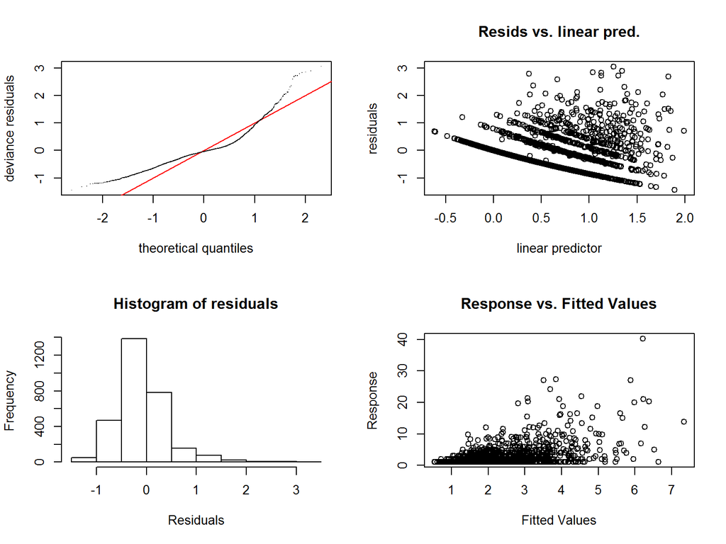

```
##
## Method: GCV   Optimizer: outer newton
## full convergence after 10 iterations.
## Gradient range [-4.093754e-10,1.254794e-08]
## (score 0.3082834 & scale 0.4649488).
## Hessian positive definite, eigenvalue range [0.0001476251,0.002308775].
## Model rank =  313 / 313
##
## Basis dimension (k) checking results. Low p-value (k-index<1) may
## indicate that k is too low, especially if edf is close to k'.
##
##                         k'   edf k-index p-value
## s(STARTLON,STARTLAT) 119.0  96.4    0.93   0.005 **
## s(AVG.DEPTH)          59.0  10.4    0.92   0.005 **
## s(OXYBOTM)            58.0   7.7    0.95   0.120
## s(SALBOTM)            58.0  42.2    0.96   0.340
## s(YEAR)               18.0  15.9      NA      NA
## ---
## Signif. codes:  0 '***' 0.001 '**' 0.01 '*' 0.05 '.' 0.1 ' ' 1
```

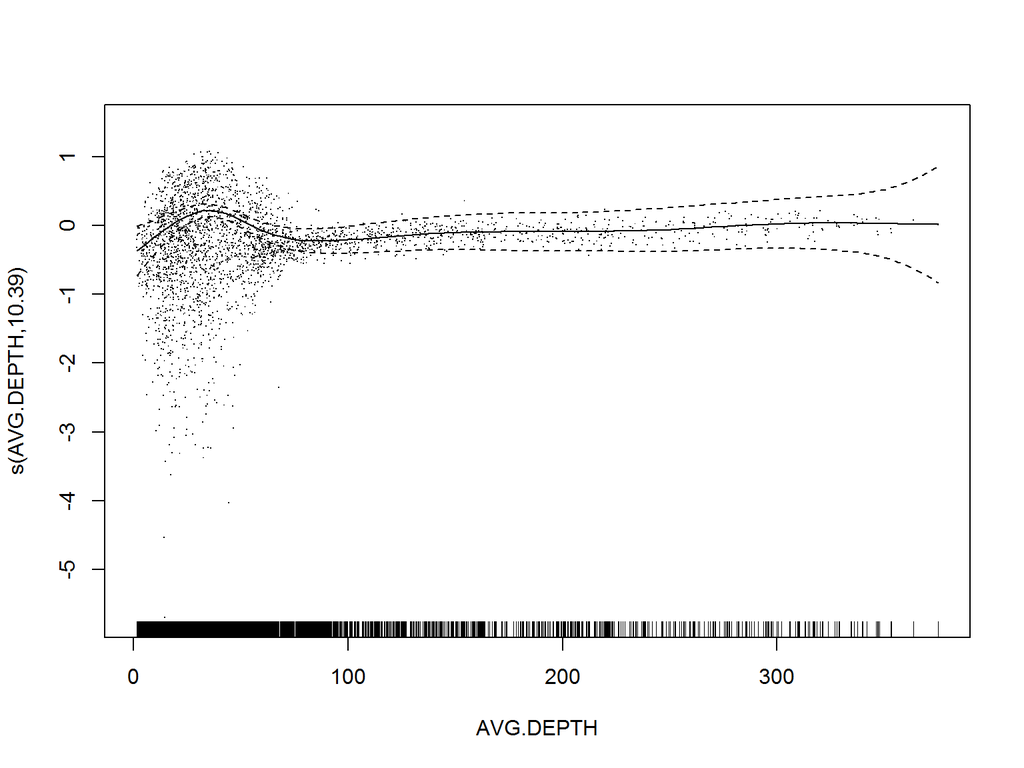

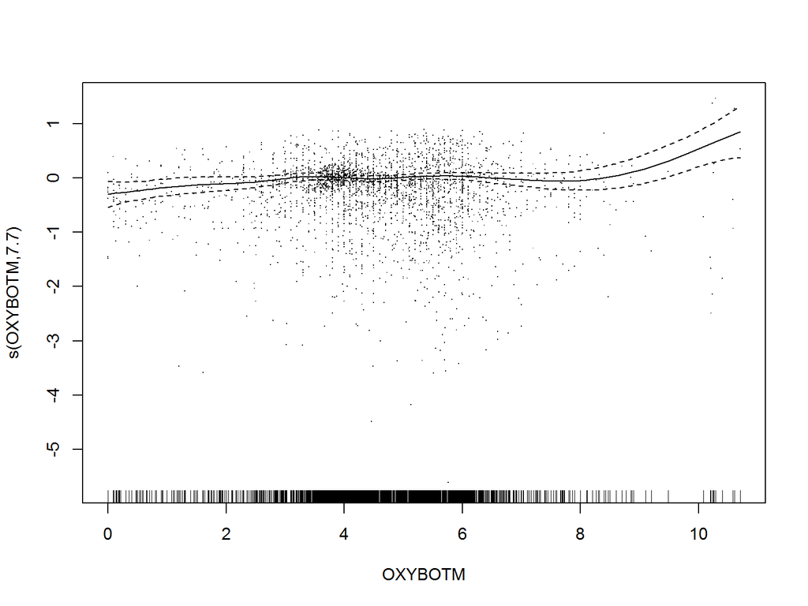

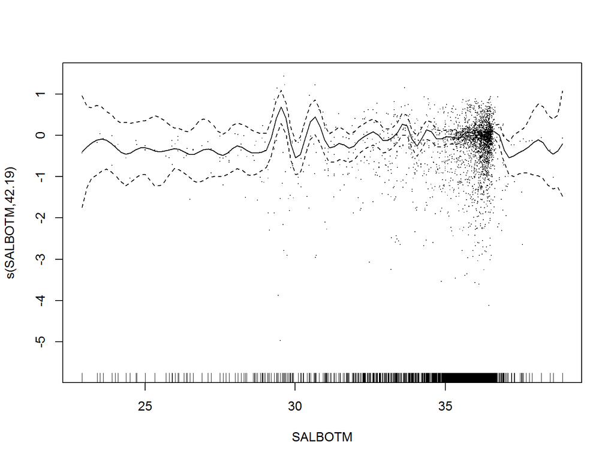

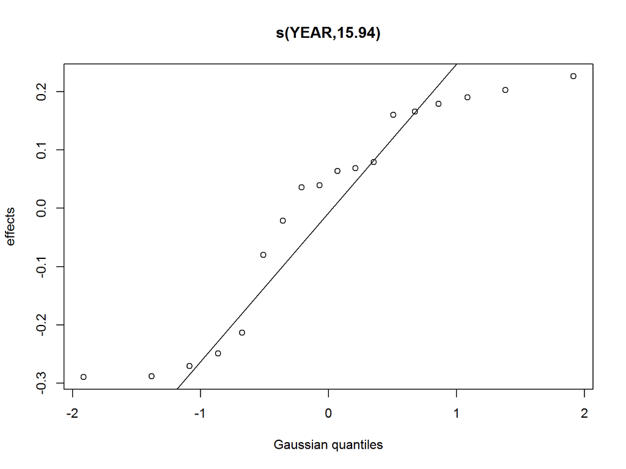

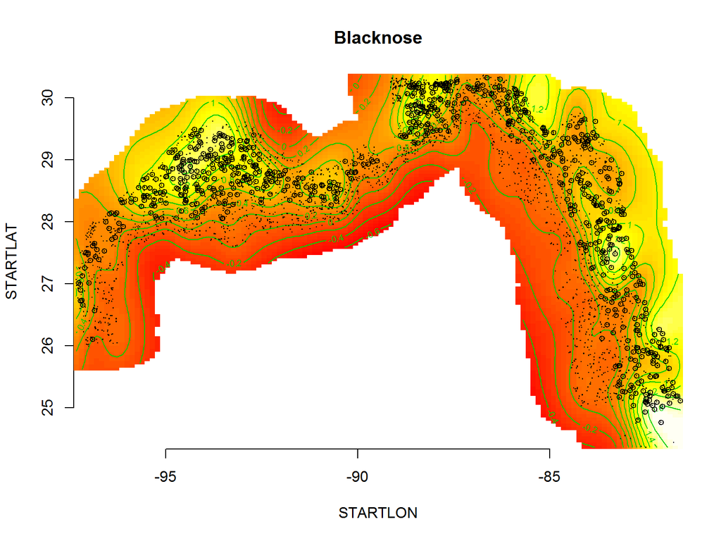

### Blacktip

```
##
## Family: Gamma
## Link function: log
##
## Formula:
## (cpe + 1) ~ s(STARTLON, STARTLAT, k = est_k(dat)$lat + est_k(dat)$lon) +
##     s(AVG.DEPTH, k = est_k(dat)$dep) + s(OXYBOTM, k = est_k(dat)$oxy) +
##     s(SALBOTM, k = est_k(dat)$sal) + s(YEAR, bs = "re", k = 18)
##
## Parametric coefficients:
##             Estimate Std. Error t value Pr(>|t|)
## (Intercept)  0.34030    0.03561   9.555   <2e-16 ***
## ---
## Signif. codes:  0 '***' 0.001 '**' 0.01 '*' 0.05 '.' 0.1 ' ' 1
##
## Approximate significance of smooth terms:
##                         edf  Ref.df     F  p-value
## s(STARTLON,STARTLAT) 96.135 111.507 5.625  < 2e-16 ***
## s(AVG.DEPTH)          8.270  10.493 3.857 2.45e-05 ***
## s(OXYBOTM)            5.182   6.536 5.229 1.34e-05 ***
## s(SALBOTM)           53.005  56.877 3.180 2.90e-14 ***
## s(YEAR)              14.972  17.000 5.285 4.66e-14 ***
## ---
## Signif. codes:  0 '***' 0.001 '**' 0.01 '*' 0.05 '.' 0.1 ' ' 1
##
## R-sq.(adj) =  0.341   Deviance explained = 62.8%
## GCV = 0.23938  Scale est. = 0.32411   n = 2963
```

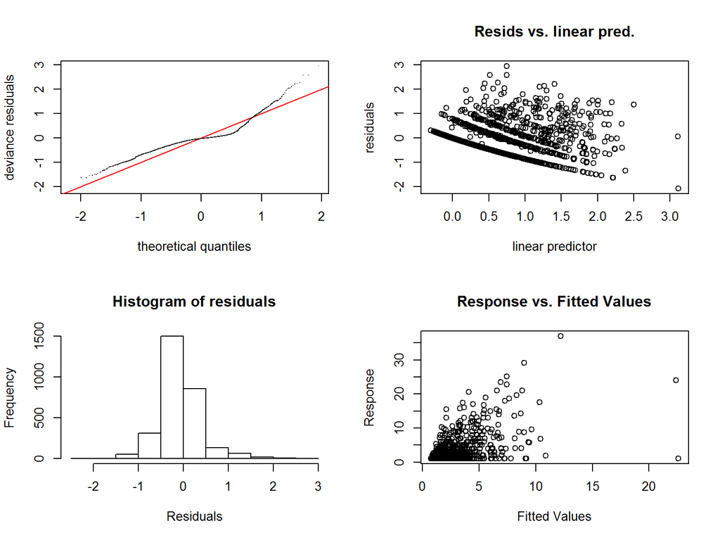

```
##
## Method: GCV   Optimizer: outer newton
## full convergence after 5 iterations.
## Gradient range [-3.105725e-11,5.564716e-09]
## (score 0.2393816 & scale 0.3241066).
## Hessian positive definite, eigenvalue range [0.0001663011,0.00144399].
## Model rank =  313 / 313
##
## Basis dimension (k) checking results. Low p-value (k-index<1) may
## indicate that k is too low, especially if edf is close to k'.
##
##                          k'    edf k-index p-value
## s(STARTLON,STARTLAT) 119.00  96.14    0.93  <2e-16 ***
## s(AVG.DEPTH)          59.00   8.27    0.93   0.005 **
## s(OXYBOTM)            58.00   5.18    0.95   0.100 .
## s(SALBOTM)            58.00  53.00    1.00   0.870
## s(YEAR)               18.00  14.97      NA      NA
## ---
## Signif. codes:  0 '***' 0.001 '**' 0.01 '*' 0.05 '.' 0.1 ' ' 1
```

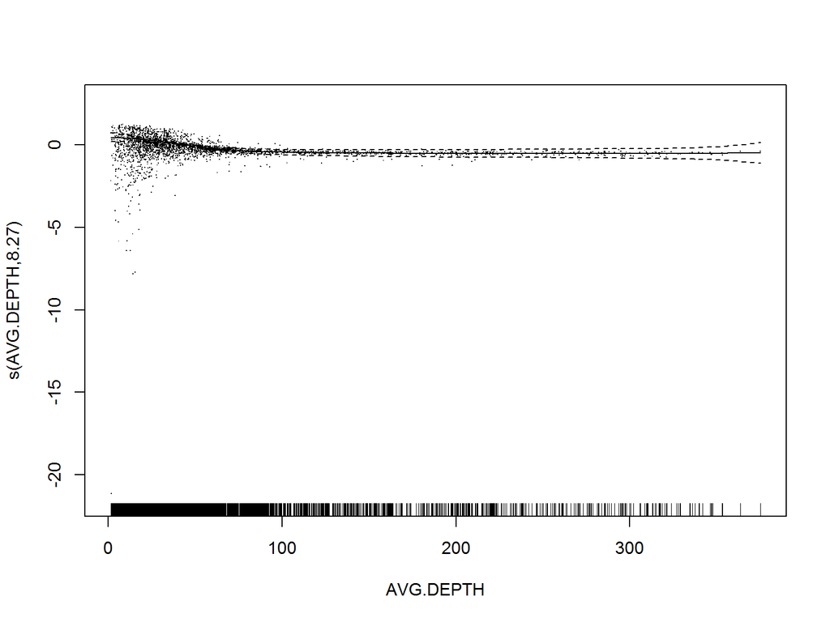

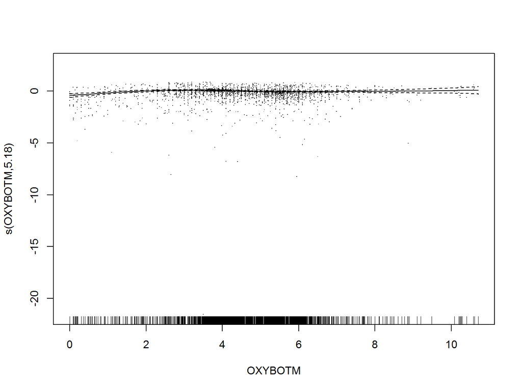

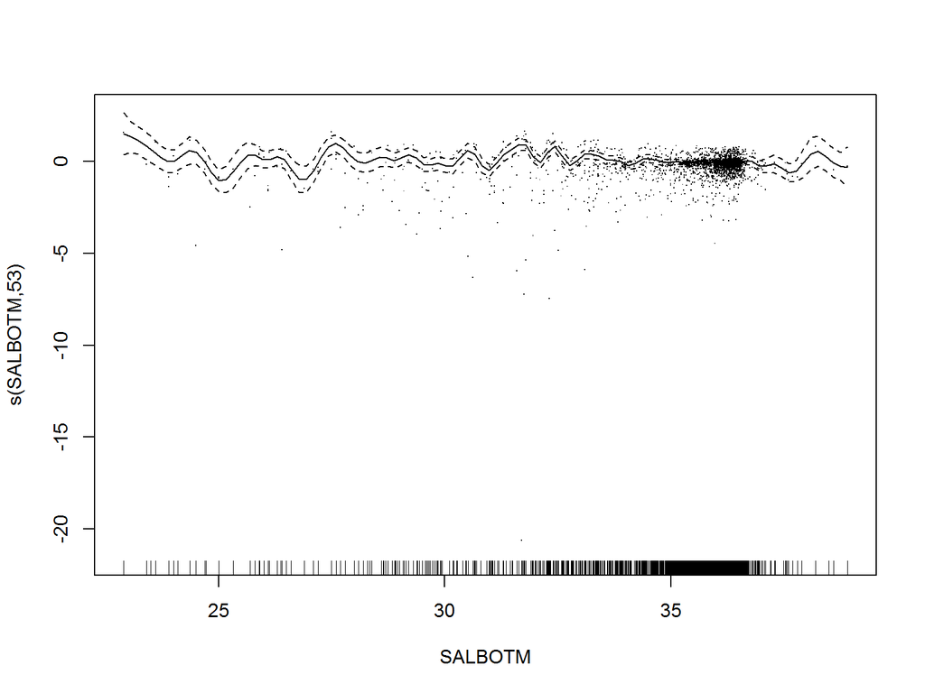

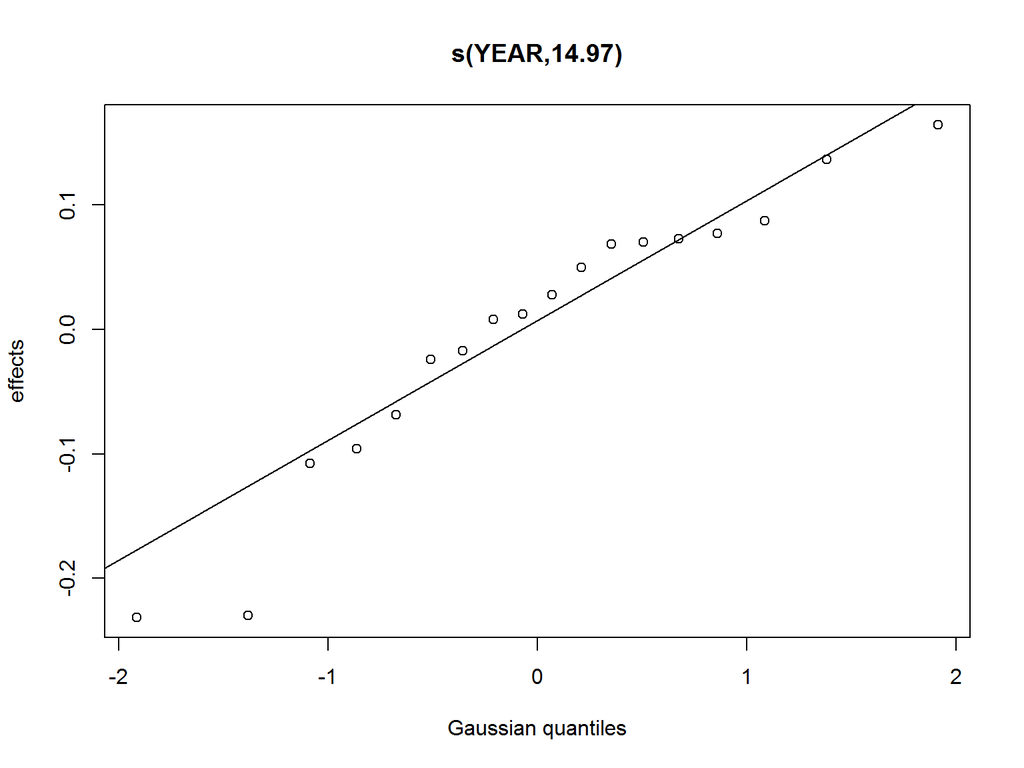

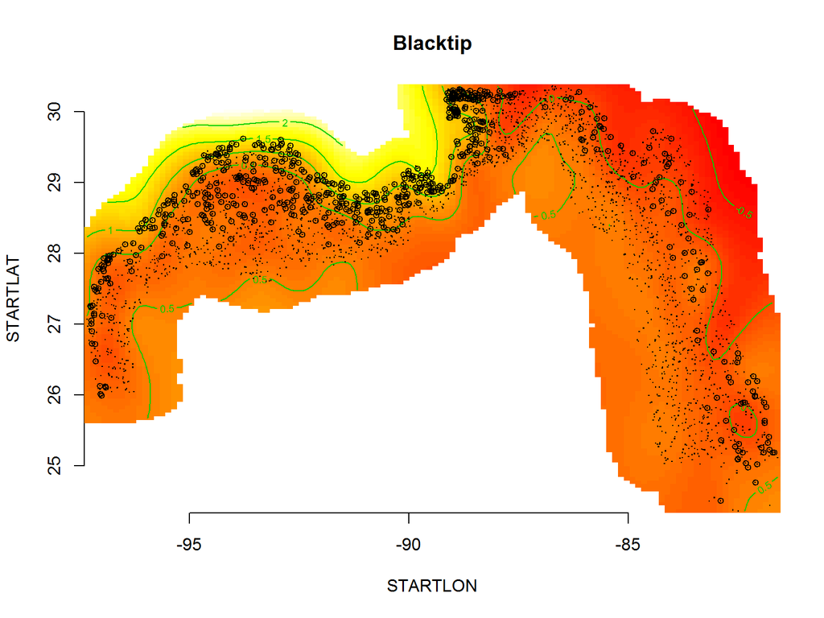

### Bull

```
##
## Family: Gamma
## Link function: log
##
## Formula:
## (cpe + 1) ~ s(STARTLON, STARTLAT, k = est_k(dat)$lat + est_k(dat)$lon) +
##     s(OXYBOTM, k = est_k(dat)$oxy) + s(SALBOTM, k = est_k(dat)$sal) +
##     s(YEAR, bs = "re", k = 18)
##
## Parametric coefficients:
##             Estimate Std. Error t value Pr(>|t|)
## (Intercept) 0.079752   0.009554   8.347   <2e-16 ***
## ---
## Signif. codes:  0 '***' 0.001 '**' 0.01 '*' 0.05 '.' 0.1 ' ' 1
##
## Approximate significance of smooth terms:
##                        edf Ref.df     F  p-value
## s(STARTLON,STARTLAT) 91.83 108.88 3.277  < 2e-16 ***
## s(OXYBOTM)           34.05  41.12 1.246   0.1349
## s(SALBOTM)           54.53  57.42 2.351 4.24e-08 ***
## s(YEAR)              10.68  17.00 1.057   0.0376 *
## ---
## Signif. codes:  0 '***' 0.001 '**' 0.01 '*' 0.05 '.' 0.1 ' ' 1
##
## R-sq.(adj) =  0.238   Deviance explained = 42.1%
## GCV = 0.053269  Scale est. = 0.079366  n = 2964
```

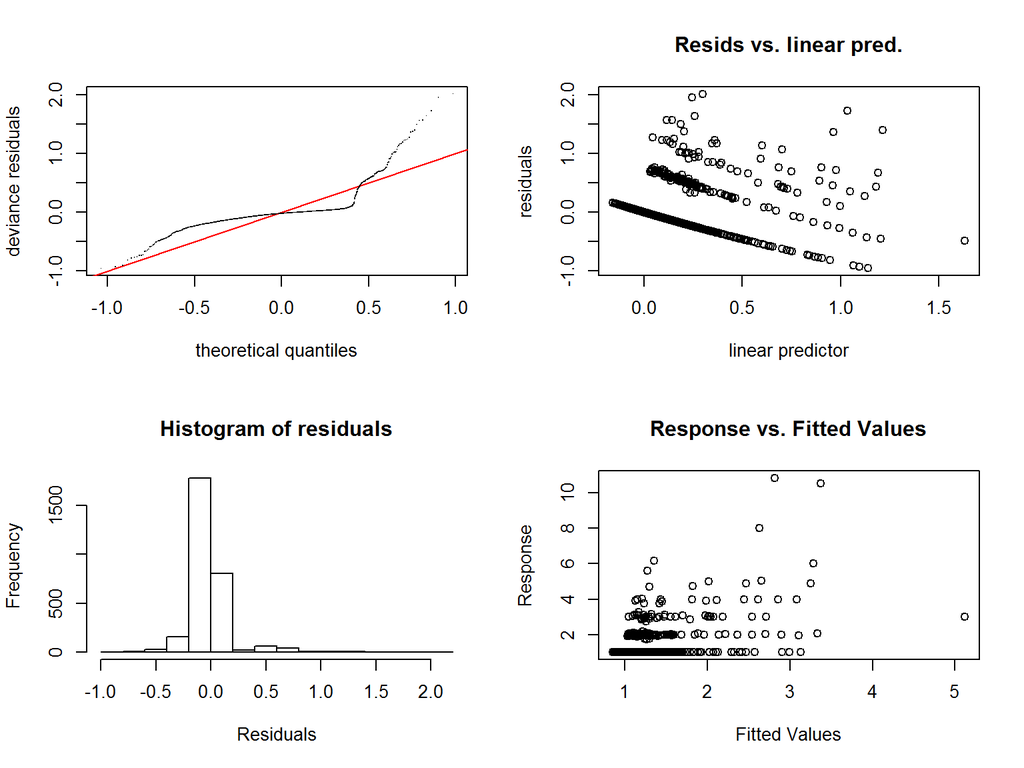

```
##
## Method: GCV   Optimizer: outer newton
## full convergence after 6 iterations.
## Gradient range [-1.987975e-10,1.410413e-08]
## (score 0.05326898 & scale 0.07936612).
## Hessian positive definite, eigenvalue range [8.185013e-05,0.0003331954].
## Model rank =  254 / 254
##
## Basis dimension (k) checking results. Low p-value (k-index<1) may
## indicate that k is too low, especially if edf is close to k'.
##
##                         k'   edf k-index p-value
## s(STARTLON,STARTLAT) 119.0  91.8    1.02    0.85
## s(OXYBOTM)            58.0  34.1    1.01    0.83
## s(SALBOTM)            58.0  54.5    1.04    1.00
## s(YEAR)               18.0  10.7      NA      NA
```

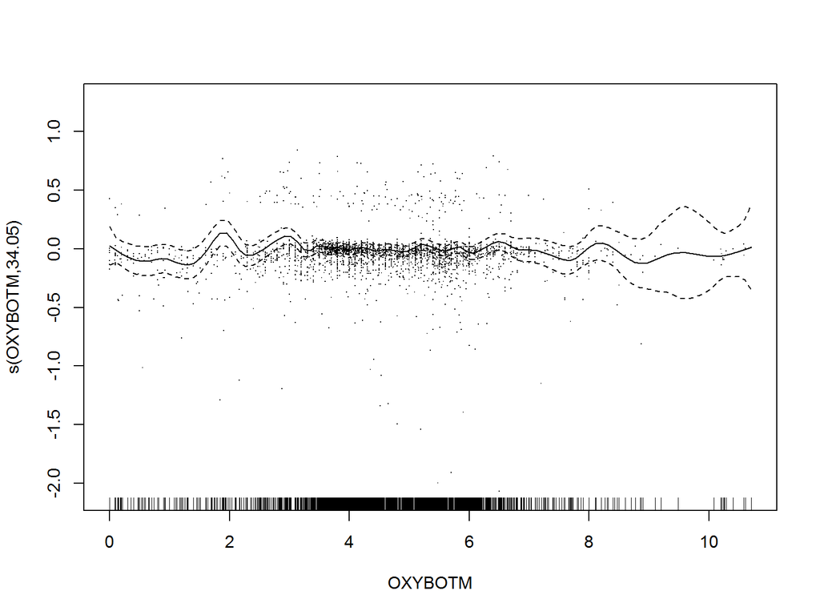

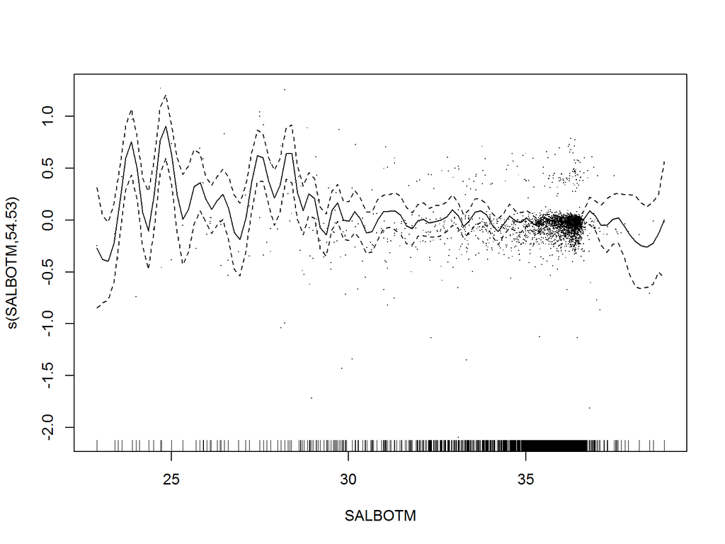

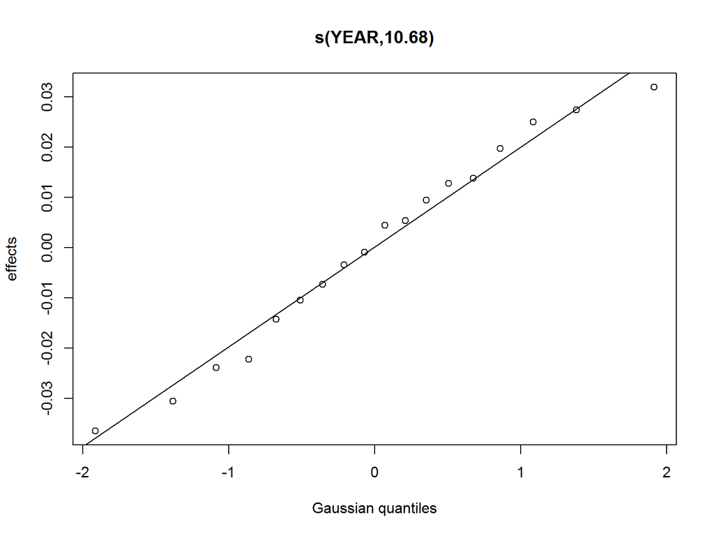

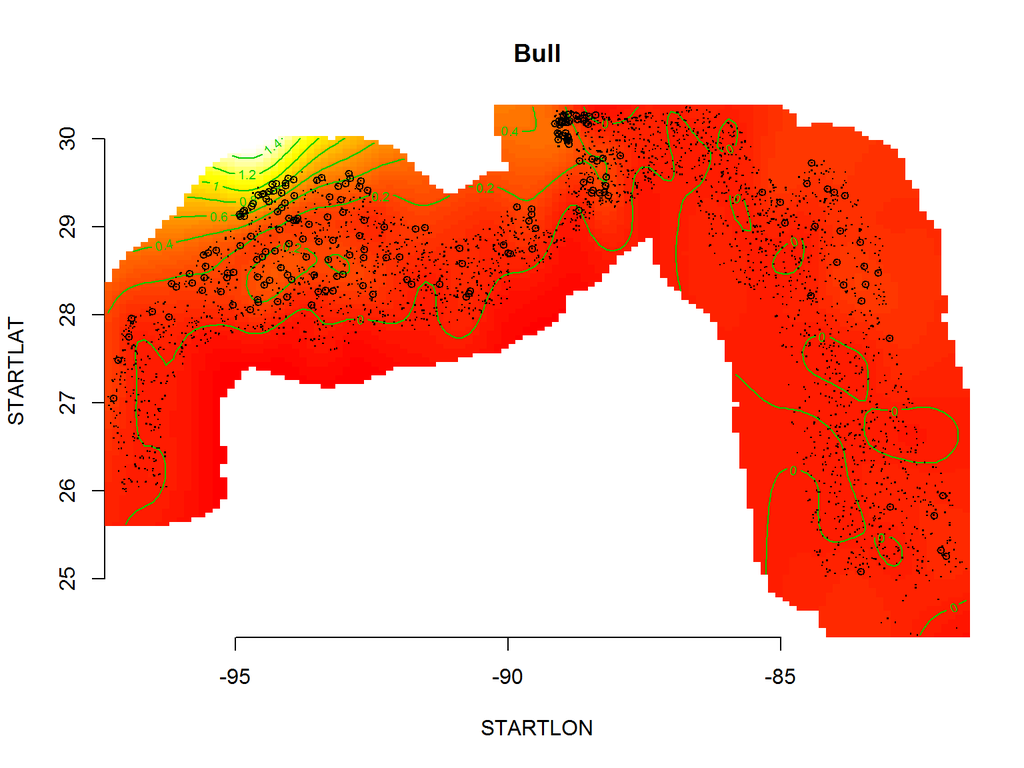

### Sandbar

```
##
## Family: Gamma
## Link function: log
##
## Formula:
## (cpe + 1) ~ s(STARTLON, STARTLAT, k = est_k(dat)$lat + est_k(dat)$lon) +
##     s(AVG.DEPTH, k = est_k(dat)$dep) + s(OXYBOTM, k = est_k(dat)$oxy) +
##     s(SALBOTM, k = est_k(dat)$sal) + s(YEAR, bs = "re", k = 18)
##
## Parametric coefficients:
##             Estimate Std. Error t value Pr(>|t|)
## (Intercept)  0.16749    0.03354   4.993 6.29e-07 ***
## ---
## Signif. codes:  0 '***' 0.001 '**' 0.01 '*' 0.05 '.' 0.1 ' ' 1
##
## Approximate significance of smooth terms:
##                         edf  Ref.df      F p-value
## s(STARTLON,STARTLAT) 89.706 107.295  3.456  <2e-16 ***
## s(AVG.DEPTH)          6.456   8.180 12.083  <2e-16 ***
## s(OXYBOTM)            7.034   8.820  0.812   0.550
## s(SALBOTM)            1.085   1.162  0.360   0.633
## s(YEAR)              15.757  17.000  8.462  <2e-16 ***
## ---
## Signif. codes:  0 '***' 0.001 '**' 0.01 '*' 0.05 '.' 0.1 ' ' 1
##
## R-sq.(adj) =  0.171   Deviance explained = 36.1%
## GCV = 0.11978  Scale est. = 0.18468   n = 2963
```

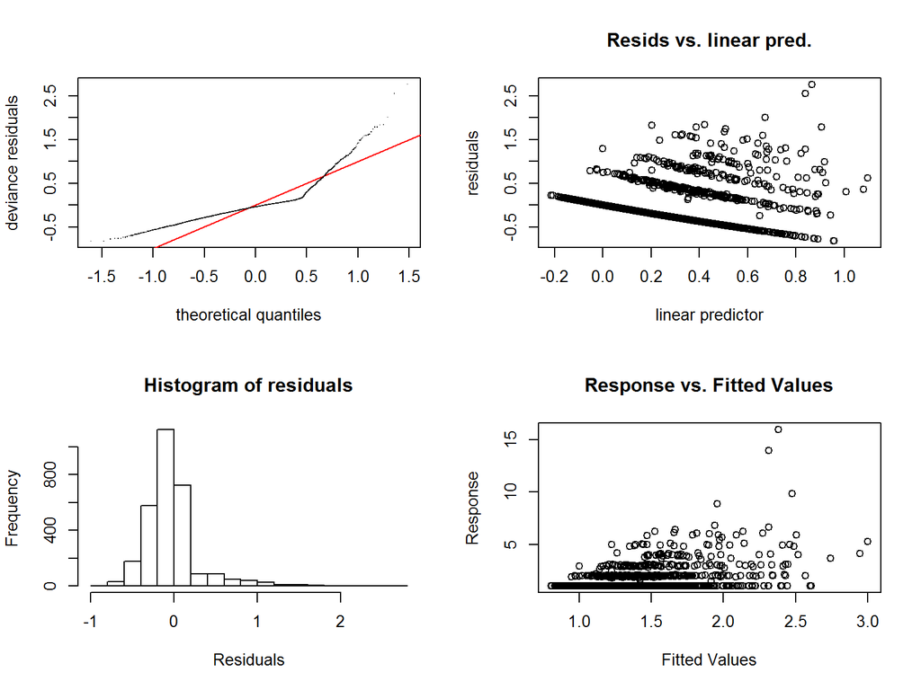

```
##
## Method: GCV   Optimizer: outer newton
## full convergence after 6 iterations.
## Gradient range [-9.797294e-09,2.787186e-07]
## (score 0.1197806 & scale 0.1846787).
## Hessian positive definite, eigenvalue range [6.546614e-07,0.000675521].
## Model rank =  313 / 313
##
## Basis dimension (k) checking results. Low p-value (k-index<1) may
## indicate that k is too low, especially if edf is close to k'.
##
##                          k'    edf k-index p-value
## s(STARTLON,STARTLAT) 119.00  89.71    0.99    0.51
## s(AVG.DEPTH)          59.00   6.46    0.96    0.09 .
## s(OXYBOTM)            58.00   7.03    1.01    0.84
## s(SALBOTM)            58.00   1.08    0.98    0.30
## s(YEAR)               18.00  15.76      NA      NA
## ---
## Signif. codes:  0 '***' 0.001 '**' 0.01 '*' 0.05 '.' 0.1 ' ' 1
```

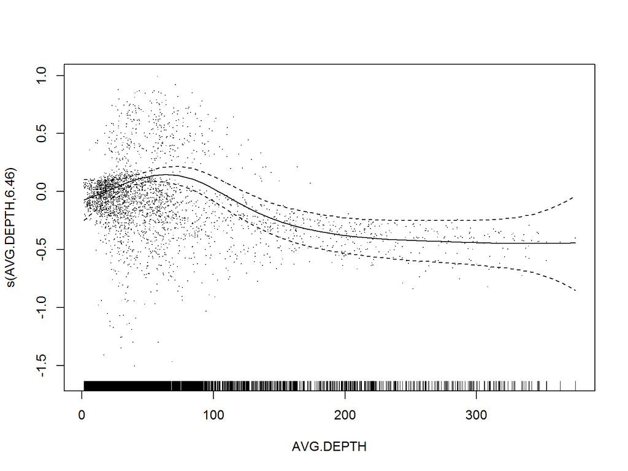

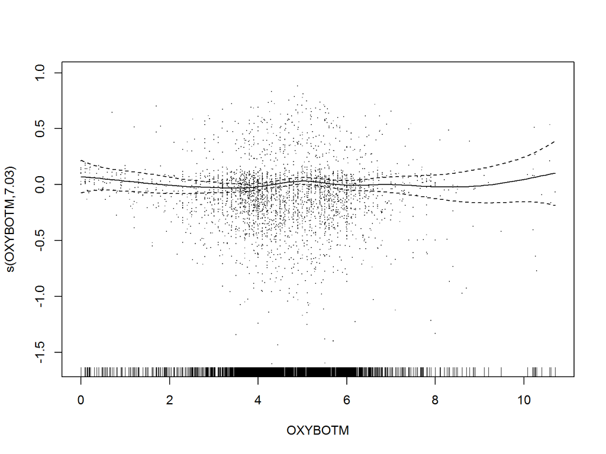

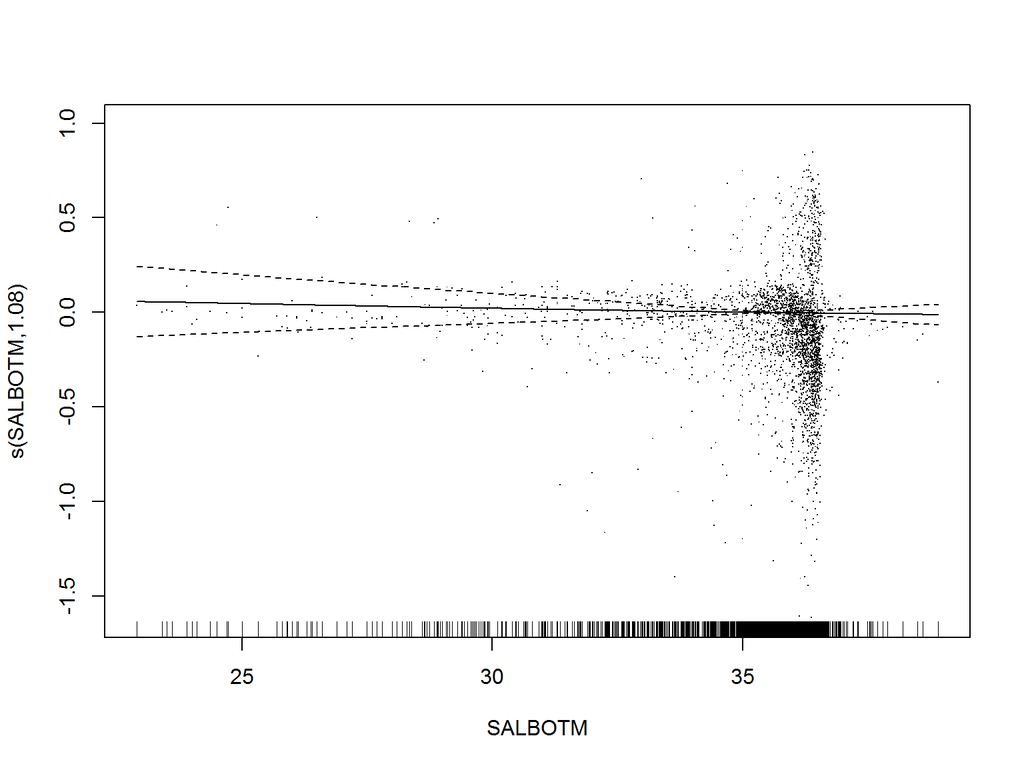

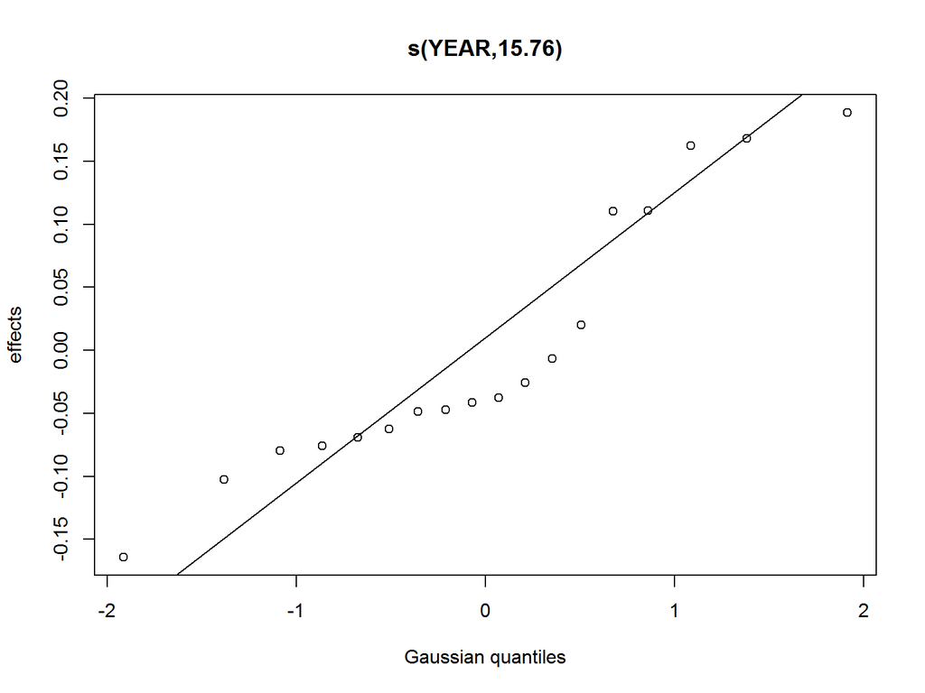

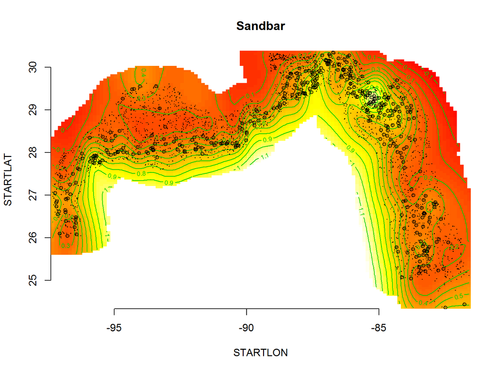

### Sharpnose

```
##
## Family: Gamma
## Link function: log
##
## Formula:
## (cpe + 1) ~ s(STARTLON, STARTLAT, k = est_k(dat)$lat + est_k(dat)$lon) +
##     s(AVG.DEPTH, k = est_k(dat)$dep) + s(OXYBOTM, k = est_k(dat)$oxy) +
##     s(SALBOTM, k = est_k(dat)$sal) + s(YEAR, bs = "re", k = 18)
##
## Parametric coefficients:
##             Estimate Std. Error t value Pr(>|t|)
## (Intercept)   1.1254     0.1027   10.95   <2e-16 ***
## ---
## Signif. codes:  0 '***' 0.001 '**' 0.01 '*' 0.05 '.' 0.1 ' ' 1
##
## Approximate significance of smooth terms:
##                          edf  Ref.df      F p-value
## s(STARTLON,STARTLAT) 107.988 117.060 12.951 < 2e-16 ***
## s(AVG.DEPTH)          19.566  24.457 11.244 < 2e-16 ***
## s(OXYBOTM)             1.001   1.001  6.994 0.00821 **
## s(SALBOTM)            42.445  49.647  1.717 0.00140 **
## s(YEAR)               16.383  17.000 15.290 < 2e-16 ***
## ---
## Signif. codes:  0 '***' 0.001 '**' 0.01 '*' 0.05 '.' 0.1 ' ' 1
##
## R-sq.(adj) =  0.456   Deviance explained = 64.1%
## GCV = 0.6919  Scale est. = 0.8165    n = 2963
```

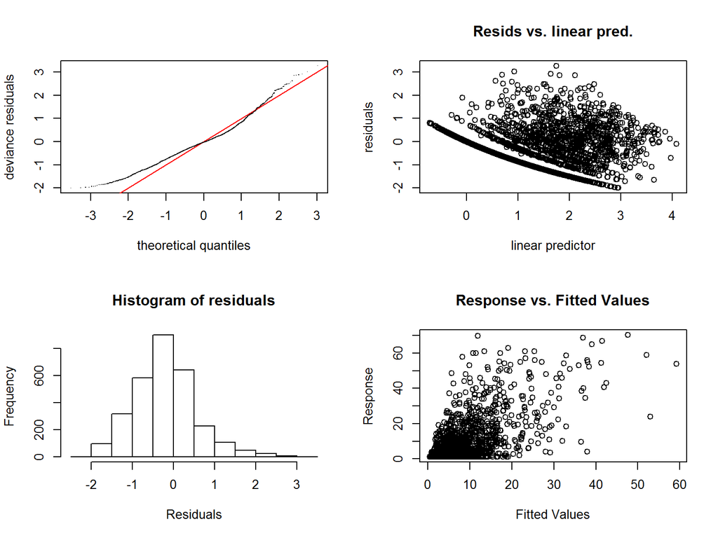

```
##
## Method: GCV   Optimizer: outer newton
## full convergence after 10 iterations.
## Gradient range [-5.567687e-08,7.252508e-07]
## (score 0.6918983 & scale 0.8164985).
## Hessian positive definite, eigenvalue range [5.556103e-08,0.002791777].
## Model rank =  313 / 313
##
## Basis dimension (k) checking results. Low p-value (k-index<1) may
## indicate that k is too low, especially if edf is close to k'.
##
##                         k'   edf k-index p-value
## s(STARTLON,STARTLAT) 119.0 108.0    0.84  <2e-16 ***
## s(AVG.DEPTH)          59.0  19.6    0.93   0.335
## s(OXYBOTM)            58.0   1.0    0.88   0.005 **
## s(SALBOTM)            58.0  42.4    0.94   0.545
## s(YEAR)               18.0  16.4      NA      NA
## ---
## Signif. codes:  0 '***' 0.001 '**' 0.01 '*' 0.05 '.' 0.1 ' ' 1
```

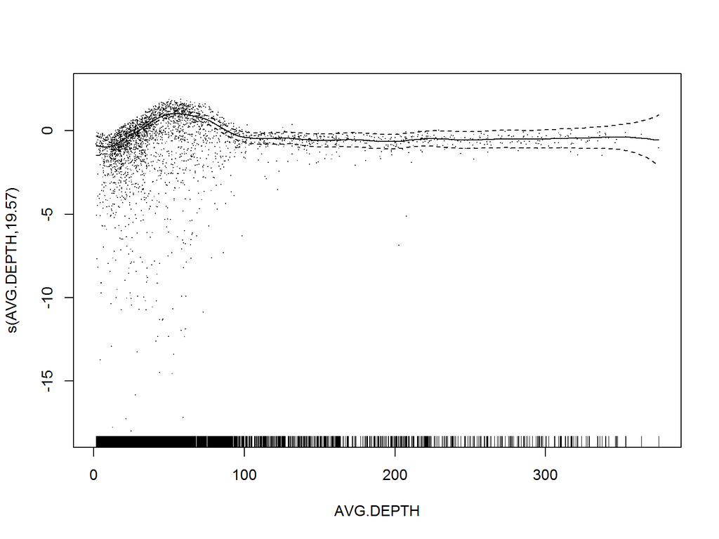

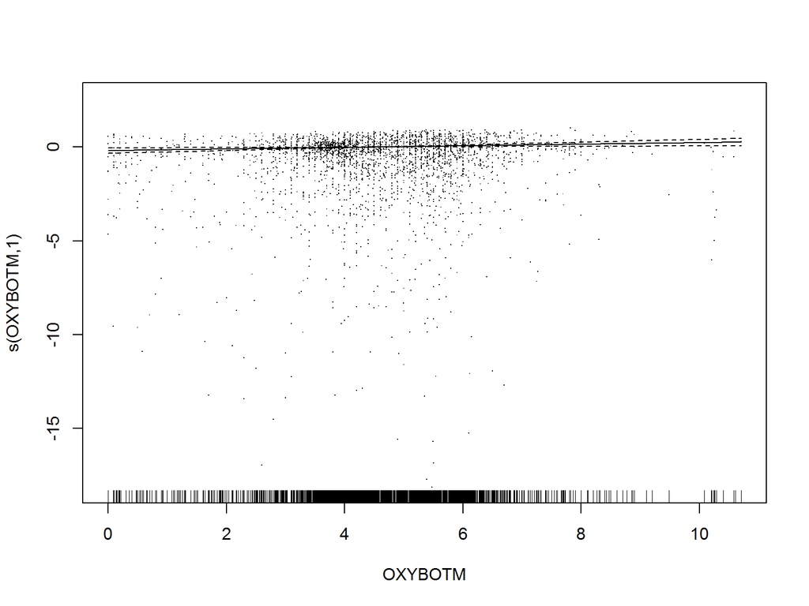